# A1_YunyiCheng

2024-02-10

## 1. Introduction

In this notebook, we will be preprocessing a GEO dataset for further analysis. This notebook was developed by *Yunyi Cheng* and runs under Docker image in the BCB420 GitHub repository.

### 1.1 Brief introduction of the study

This analysis is informed by recent findings on sex-dependent gene expression changes in Parkinson’s disease(PD)<sup>1</sup>. They highlight PD as a heterogeneous disorder where biological sex significantly influences symptom profiles, with males typically having higher disease incidence and muscle rigidity, while females more often present with disabling tremors. The molecular mechanisms behind these sex-dependent differences remain largely unknown.

To address this, the authors conducted a meta-analysis of brain transcriptomics data from case/control studies, identifying both sex-specific alterations (changes observed in only one sex) and sex-dimorphic changes (changes in both sexes but in opposite directions). They further explored these changes through systems-level pathway and network analyses, which unveiled significant sex differences in mitochondrial pathways and highlighted specific regulatory factors. These factors’ activity changes could explain the observed network alterations through gene regulatory cascades. The study also utilized single-cell expression data analyses to confirm the main pathway-level changes identified in bulk transcriptomics data.

## 2. Data Cleaning and HUGO Mapping

### 2.1 Download Dataset

```r
# Create a 'geoCache' directory in the current working directory to
# avoid re-downloading the data each time we run the notebook
cacheDir <- file.path(getwd(), "geoCache")
if (!dir.exists(cacheDir)) {
  dir.create(cacheDir)
}

# GEO accession number
gseID <- "GSE168496"

# Download and read the GEO series
gse <- GEOquery::getGEO(gseID, destdir=cacheDir, GSEMatrix =TRUE, getGPL=FALSE)
```

```
## Found 1 file(s)
```

```
## GSE168496_series_matrix.txt.gz
```

```
## Using locally cached version: /home/rstudio/projects/Desktop/BCB420/GitHub/A1/geoCache/GSE168496_series_matrix.txt.gz
```

```r
# Extract the instance of GSE series since gse is a list of length 1
if (is.list(gse)) {
  gse <- gse[[1]]
}

# Create the full path to the local file
localFilePath <- file.path(
  cacheDir, "GSE168496_all_samples_preprocessed_data.tsv.gz")

# Check if the file already exists before downloading
if (!file.exists(localFilePath)) {
  # Download the file only if it doesn't already exist in the cache directory
  GEOquery::getGEOSuppFiles(gseID, makeDirectory = FALSE, baseDir = cacheDir)
}

# Proceed to check if the file exists and read it
if (file.exists(localFilePath)) {
  # Read the gzipped TSV file into a data frame
  rawData <- readr::read_tsv(localFilePath)
  print(head(rawData))
} else {
  stop("The dataset file was not successfully downloaded or found.")
}
```

```
## # A tibble: 6 × 17
##   id           `1996-105` `1997-042` `2000-025` `2001-139` `2003-035` `2009-039`
##   <chr>             <dbl>      <dbl>      <dbl>      <dbl>      <dbl>      <dbl>
## 1 ENST0000000…     1282.       1251.      1415.     1099.       1233.      1309.
## 2 ENST0000000…     1668.        909.      1336.     1416.       1269.      1179.
## 3 ENST0000000…      479.        671.       414.      863.        250.       283.
## 4 ENST0000000…     2377.       2406.      3345.     1927.       1930.      2785.
## 5 ENST0000000…       33.8       129.         0        51.6         0          0
## 6 ENST0000000…      272.        247.       305.      186.        212.       265.
## # ℹ 10 more variables: `2012-067` <dbl>, `2016-016` <dbl>, `2016-023` <dbl>,
## #   `2016-051` <dbl>, `2017-012` <dbl>, `2017-016` <dbl>, `2017-041` <dbl>,
## #   `2017-056` <dbl>, `2017-059` <dbl>, `2017-079` <dbl>
```

### 2.2 Preprocess Dataset

#### 2.2.1 Change Column Names to GSM numbers

As we can see the column names of `rawData` are not very informative about the experiment. Note that each column name corresponds to one GEO sample, thus we will change the column names to GEO Sample Numbers (GSM), which uniquely identify samples that were used in an experiment.

```r
# Create a vector of the new column names based on the GSM numbers
gsmNumbers <- c("GSM5144785", "GSM5144786", "GSM5144787", "GSM5144788",
                "GSM5144789", "GSM5144790", "GSM5144791", "GSM5144792",
                "GSM5144793", "GSM5144794", "GSM5144795", "GSM5144796",
                "GSM5144797", "GSM5144798", "GSM5144799", "GSM5144800")


# Ensure the length of 'gsmNumbers' matches num column in 'rawData'
# Skip the first column which contains gene identifiers
if (length(gsmNumbers) == ncol(rawData) - 1) {
  # Assign the new column names to 'rawData'
  colnames(rawData)[-1] <- gsmNumbers
} else {
  stop("The number of GSM numbers
       does not match the number of columns in the dataframe.")
}

# Check the new column names
colnames(rawData)
```

```
##  [1] "id"         "GSM5144785" "GSM5144786" "GSM5144787" "GSM5144788"
##  [6] "GSM5144789" "GSM5144790" "GSM5144791" "GSM5144792" "GSM5144793"
## [11] "GSM5144794" "GSM5144795" "GSM5144796" "GSM5144797" "GSM5144798"
## [16] "GSM5144799" "GSM5144800"
```

#### 2.2.2 Map ENSEMBL IDs to HUGO Symbols

To map ENSEMBL IDs (which start with “ENST”) to HUGO gene symbols, we can use the biomaRt package in R to query the ENSEMBL database. But first of all, we need to check for invalid ENSEMBL IDs in `rawData` and remove them.

```r
# Function to filter out invalid ENSEMBL IDs
filterInvalidEnsemblIDs <- function(rawData) {
  # Define the regex pattern for ENSEMBL transcript IDs
  pattern <- "^ENST\\d{11}(\\.\\d+)?$"

  # Find which IDs are valid
  validIDs <- sapply(rawData$id, function(id) grepl(pattern, id))

  # Count invalid IDs
  numInvalidIDs <- sum(!validIDs)

  # Print the number of invalid IDs
  message("There are ", numInvalidIDs, " invalid ENSEMBL IDs.")

  # Filter out invalid IDs
  validData <- rawData[validIDs, ]

  return(validData)
}

# Apply the function to remove invalid entries and get the filtered data
filteredData <- filterInvalidEnsemblIDs(rawData)
```

```
## There are 0 invalid ENSEMBL IDs.
```

Now we can map ENSEMBL IDs to HUGO gene symbols.

```r
# Use biomaRt to map ENSEMBL IDs to HUGO symbols
mapEnsemblToHugo <- function(filteredData) {
  ensembl <- biomaRt::useMart("ensembl", dataset = "hsapiens_gene_ensembl")
  ensemblIds <- filteredData$id
  getSymbols <- biomaRt::getBM(attributes = c('ensembl_transcript_id_version',
                                              'hgnc_symbol'),
                                filters = 'ensembl_transcript_id_version',
                                values = ensemblIds,
                                mart = ensembl)
  # Merge the symbols back into the filteredData
  filteredData <- merge(filteredData, getSymbols,
                        by.x = 'id', by.y = 'ensembl_transcript_id_version',
                        all.x = TRUE)
  return(filteredData)
}

# Map ENSEMBL IDs to HUGO symbols
filteredDataWithSymbols <- mapEnsemblToHugo(filteredData)

# Reformat filteredDataWithSymbols
filteredDataWithSymbols <- filteredDataWithSymbols %>%
  dplyr::rename(ensembl_id = id) %>%
  dplyr::select(ensembl_id, hgnc_symbol, everything())

# Identify unmapped data
unmappedData <- filteredDataWithSymbols[
  is.na(filteredDataWithSymbols$hgnc_symbol), ]

# Display number of the unmapped ENSEMBL ids
message("There are ", nrow(unmappedData), " unmapped ENSEMBL IDs.")
```

```
## There are 19716 unmapped ENSEMBL IDs.
```

```r
# Remove unmapped rows
filteredDataWithSymbols <-
  filteredDataWithSymbols[!is.na(filteredDataWithSymbols$hgnc_symbol), ]

# Remove the 'ensembl_id' column
filteredDataWithSymbols <-
  filteredDataWithSymbols %>% dplyr::select(-ensembl_id)

# Check if there are unmapped rows remain
any(is.na(filteredDataWithSymbols$hgnc_symbol))
```

```
## [1] FALSE
```

#### 2.2.3 Clean Dataset

Data cleaning has always been controversial. As supported by<sup>2</sup> and<sup>3</sup>, we often discover new stuff when focusing on such outliers. After reading several papers on whether to remove outliers, I decided to keep the data cleaning minimal, which means I only remove data points if I am very confident it is generated from errors in the experiment.

According to<sup>1</sup>, the dataset provided is already pre-cleaned by removal of samples from conditions other than idiopathic Parkinson’s Disease (PD) and healthy controls, removal of low-quality genetic probes, and probes/transcripts with zero variance.

Nonetheless, we will double-check for missing or incorrect values and remove them.

```r
# Filter out the rows where hgnc_symbol is an empty string
filteredDataWithSymbols <- filteredDataWithSymbols %>%
  dplyr::filter(hgnc_symbol != '')

# Check for negative values
print(paste("There are",
            sum(filteredDataWithSymbols[, -1] < 0), "negative values."))
```

```
## [1] "There are 0 negative values."
```

```r
negativeValues <- apply(
  filteredDataWithSymbols[, -1], 1, function(x) any(x < 0))

# Remove rows with negative values
filteredDataWithSymbols <- filteredDataWithSymbols[!negativeValues, ]

# Check for missing values
missingValues <- is.na(filteredDataWithSymbols[, -1])
print(paste("There are", sum(missingValues), "missing values."))
```

```
## [1] "There are 0 missing values."
```

```r
# Remove rows missing values
filteredDataWithSymbols <-
  filteredDataWithSymbols[rowSums(missingValues) == 0, ]

# Check if there are any NA values in the df after removing rows
anyNA(filteredDataWithSymbols)
```

```
## [1] FALSE
```

There are non-unique gene symbols which can be problematic because it can skew the analysis and interpretation of the results. To solve this, I decided to aggregate the expression values by summing them since there are notably amount of zeros.

```r
# Aggregate the expression values by summing them for each HUGO symbol
aggregatedData <- filteredDataWithSymbols %>%
  dplyr::group_by(hgnc_symbol) %>%
  dplyr::summarise(
    across(everything(), ~ sum(.x, na.rm = TRUE)), .groups = 'drop') %>%
  as.data.frame()
```

### 2.3 Preprocess Metadata for Future Analysis

We now have the dataset mapped to HUGO symbols, and we want to curate the metadata for future analysis. Many metadata are the same across the samples, so we only want to keep the different characteristics among the samples.

```r
getMetadataFromGSM <- function(gsm) {
  # Construct the path to the cached file
  localFilePath <- file.path(cacheDir, paste0(gsm, ".rda"))

  # Check if the file exists locally
  if (file.exists(localFilePath)) {
    # Load the local GSM data
    load(localFilePath)
  } else {
    # Fetch the GSM data from GEO and save it locally
    gsmData <- GEOquery::getGEO(gsm, AnnotGPL=FALSE)
    save(gsmData, file = localFilePath)
  }

  # Extract the 'characteristics_ch1' field
  characteristics <- gsmData@header$characteristics_ch1

  # Initialize an empty list to store the parsed metadata
  metadataList <- list()

  # Define the regex pattern for post-mortem delay
  # (used for special preprocessing)
  pmDelayPattern <- "(\\d+):(\\d{2}):(\\d{2})"

  for (char in characteristics) {
    # Split the string by ':' and ' ' to separate the key from the value
    charParts <- strsplit(char, ":\\s+", fixed = FALSE)

    # If the characteristic is 'post-mortem delay', apply regex to format
    if (grepl("post-mortem delay", char, ignore.case = TRUE)) {
      pmDelayMatch <- regmatches(char, regexec(pmDelayPattern, char))
      if (length(pmDelayMatch[[1]]) > 1) {  # If a match was found
        metadataList[["post-mortem delay"]] <- pmDelayMatch[[1]][2]
      } else {
        metadataList[["post-mortem delay"]] <- NA  # No valid format found
      }
    } else {
      # For other characteristics, proceed as normal
      if (length(charParts[[1]]) > 1) {
        key <- charParts[[1]][1]
        value <- charParts[[1]][2]
        metadataList[[key]] <- value
      }
    }
  }

  # Return the list of metadata as a named vector
  return(unlist(metadataList))
}

# Retrieve and store metadata for each GSM
metadataList <- lapply(gsmNumbers, getMetadataFromGSM)

# Combine all metadata into a single data frame
metadataDf <- do.call(rbind, metadataList)

# Add GSM numbers as a new column
metadataDf <- cbind(GSM = gsmNumbers, metadataDf)

# Display metadataDf
print(head(metadataDf))
```

```
##      GSM          disease state          tissue             gender
## [1,] "GSM5144785" "Non-demented control" "Substantia nigra" "Male"
## [2,] "GSM5144786" "Non-demented control" "Substantia nigra" "Female"
## [3,] "GSM5144787" "Non-demented control" "Substantia nigra" "Female"
## [4,] "GSM5144788" "Non-demented control" "Substantia nigra" "Female"
## [5,] "GSM5144789" "Non-demented control" "Substantia nigra" "Male"
## [6,] "GSM5144790" "Non-demented control" "Substantia nigra" "Male"
##      age at death (years) post-mortem delay braak amyloid braak lb apoe ph-csf
## [1,] "88"                 "05"              "4"   "N/A"   "N/A"    "43" "6.65"
## [2,] "65"                 "12"              "1"   "N/A"   "N/A"    "33" "6.94"
## [3,] "41"                 "13"              "0"   "A"     "N/A"    "43" "N/A"
## [4,] "73"                 "13"              "2"   "C"     "0"      "43" "6.3"
## [5,] "96"                 "06"              "1"   "O"     "0"      "33" "6.65"
## [6,] "82"                 "12"              "3"   "C"     "N/A"    "43" "6.21"
##      brain weight (g)
## [1,] "1120"
## [2,] "910"
## [3,] "1263"
## [4,] "1231"
## [5,] "1300"
## [6,] "1406"
```

```r
if (!is.data.frame(metadataDf)) {
  metadataDf <- as.data.frame(metadataDf)
}
is.data.frame(metadataDf)
```

```
## [1] TRUE
```

Since GSM numbers as row names are not very informative, we can combine information from metadata to specify the condition of sample for future merging.

```r
metadataDf$combinedInfo <- apply(metadataDf, 1, function(x) {
  # Abbreviate the disease state and gender for conciseness
  diseaseAbbrev <-
    ifelse(x['disease state'] == 'Non-demented control', 'Ctrl', 'PD')
  genderAbbrev <-
    substr(x['gender'], 1, 1) # 'Male' -> 'M', 'Female' -> 'F'

  # Combine the GSM number with the abbreviated disease state and gender
  paste0(x['GSM'], "_", diseaseAbbrev, "_", genderAbbrev)
})
```

```r
# Transpose filteredDataWithSymbols for merging
longData <- reshape2::melt(filteredDataWithSymbols,
                           id.vars = 'hgnc_symbol',
                           variable.name = 'GSM',
                           value.name = 'Expression')

# Merge the expression data with metadata, ensuring to include the combinedInfo
mergedData <- merge(longData, metadataDf, by = 'GSM')

# Ensure that categorical data is treated appropriately
mergedData$`disease state` <- as.factor(mergedData$`disease state`)
```

### 2.4 Assess Dataset

Now we have cleaned the dataset, mapped it to HUGO symbols and combined it with metadata, we can perform overall statistical analysis on the dataset.

```r
# Compute overview statistics by gender and disease state
overviewStatsByGenderAndDisease <- mergedData %>%
  dplyr::group_by(gender, `disease state`) %>%
  dplyr::summarise(
    Mean_Expression = mean(Expression, na.rm = TRUE),
    SD_Expression = sd(Expression, na.rm = TRUE),
    Median_Expression = median(Expression, na.rm = TRUE),
    IQR_Expression = IQR(Expression, na.rm = TRUE),
    .groups = 'drop' # Drop the grouping structure afterwards
  )

# Display the results
print(overviewStatsByGenderAndDisease)
```

```
## # A tibble: 4 × 6
##   gender `disease state`      Mean_Expression SD_Expression Median_Expression
##   <chr>  <fct>                          <dbl>         <dbl>             <dbl>
## 1 Female Non-demented control            155.         6214.             0.189
## 2 Female Parkinson's disease             128.         3354.             0.916
## 3 Male   Non-demented control            142.         4526.             0.287
## 4 Male   Parkinson's disease             133.         3972.             0.819
## # ℹ 1 more variable: IQR_Expression <dbl>
```

We can see that there are some notable differences between female and male, as well as between control and Parkinson’s samples. We will further explore the dataset after normalization.

## 3. Normalization

### 3.1 Reformat Dataset

Before normalization, we need to reformat the data frame so that it has 16 numeric columns (for 16 samples) and unique HUGO symbols as row names.

```r
# Set the HUGO symbols as rownames and remove the previous column of HUGO symbol
rownames(aggregatedData) <- aggregatedData$hgnc_symbol
aggregatedData$hgnc_symbol <- NULL
```

```r
# Now to apply combinedInfo as column names in aggregatedData
names(aggregatedData) <- metadataDf$combinedInfo
names(aggregatedData)
```

```
##  [1] "GSM5144785_Ctrl_M" "GSM5144786_Ctrl_F" "GSM5144787_Ctrl_F"
##  [4] "GSM5144788_Ctrl_F" "GSM5144789_Ctrl_M" "GSM5144790_Ctrl_M"
##  [7] "GSM5144791_Ctrl_M" "GSM5144792_PD_F"   "GSM5144793_PD_M"
## [10] "GSM5144794_PD_M"   "GSM5144795_PD_M"   "GSM5144796_Ctrl_M"
## [13] "GSM5144797_PD_M"   "GSM5144798_PD_F"   "GSM5144799_PD_F"
## [16] "GSM5144800_PD_M"
```

### 3.2 Pre-normalization Plots

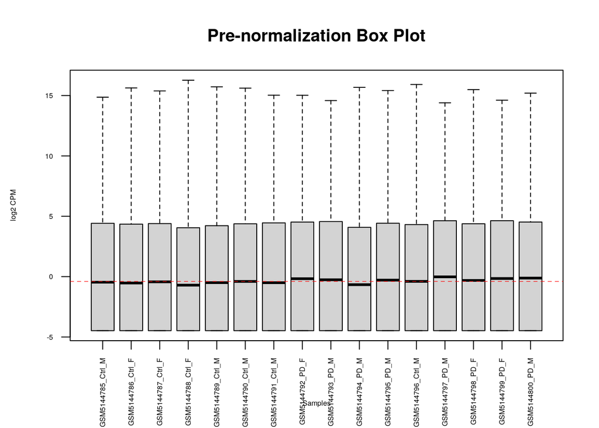

```r
# Convert it to DGEList
dge <- DGEList(counts=aggregatedData)

# Compute CPM and add a pseudocount of for numerical stability
cpmDataPre <- edgeR::cpm(dge, log = TRUE, prior.count = 1)

# Plot the box plot
graphics::boxplot(cpmDataPre, xlab = "Samples", ylab = "log2 CPM",
 las = 2, cex = 0.5, cex.lab = 0.5,
 cex.axis = 0.5, main = "Pre-normalization Box Plot")

# Draw the median on each box plot
abline(h = median(apply(cpmDataPre, 2, median)),
 col = "red", lwd = 0.6, lty = "dashed")
```

We can see that the data is heavily skewed towards higher values when log-transformed. It is because most genes have low read counts and a few have very high read counts. I added a pseudocount of 1 before log transformation, ensuring that there are no log-transformed values of negative infinity, which would result from taking the log of zero. The presence of data points below zero suggests that there are some expression values that are, on a CPM basis, less than 1. This is entirely possible, especially for lowly expressed genes.

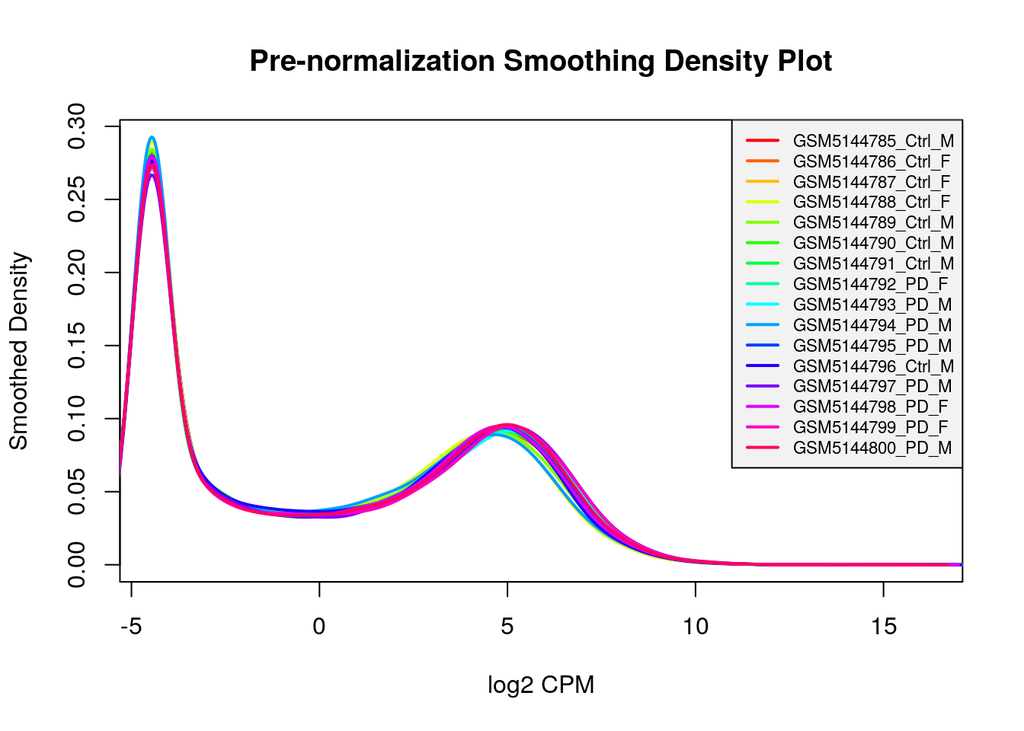

```r
# Calculate the density for each sample and plot it
plot(NULL, xlim = range(cpmDataPre),
     ylim = c(0, max(sapply(1:ncol(cpmDataPre), function(i) {
  max(density(cpmDataPre[, i])$y)
}))),
xlab = "log2 CPM", ylab = "Smoothed Density",
main = "Pre-normalization Smoothing Density Plot")

# Add a color palette
colors <- rainbow(ncol(cpmDataPre))

# Plot the density for each sample
for (i in 1:ncol(cpmDataPre)) {
  dens <- density(cpmDataPre[, i])
  lines(dens, col = colors[i], lwd = 2)
}

# Add a legend to identify the samples
legend("topright", legend = colnames(cpmDataPre), cex=0.7, col = colors,
       bg = "gray95", lwd = 2)
```

We can see that the curves are almost identical to each other, which implied that this dataset has possibly undergone some normalization process before it is submitted. Nonetheless, we will still apply normalization to see if there is a difference.

### 3.3 TMM Normalization

I chose TMM normalization for this dataset due to the following benefits:

1. **Effectiveness in handling compositional differences** between samples.
2. **Robustness against outliers**, ensuring stability in diverse datasets.
3. **Computational efficiency**, facilitating its use in large-scale studies.

These factors make TMM a suitable choice for accurately comparing gene expression across different conditions, essential in research exploring complex biological phenomena like sex-dependent differences in disease.

```r
# Calculate normalization factors, by default it uses the TMM method
dge <- edgeR::calcNormFactors(dge)

# Get normalized counts
normCounts <-
  dge$counts / dge$samples$norm.factors * mean(dge$samples$lib.size)

# Calculate CPM with edgeR and log2-transform the data
cpmDataPost <- edgeR::cpm(dge, log = TRUE, prior.count = 1)
```

```r
# Convert to a data frame
normalizedCpmDf <- as.data.frame(cpmDataPost)

# Write the normalized CPM to a CSV file
write.csv(normalizedCpmDf, file="a1NormalizedCpmDf.csv", row.names=TRUE)
```

### 3.4 Post-normalization Plots

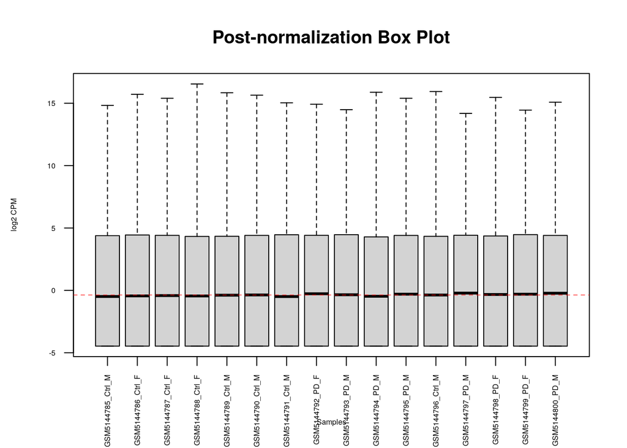

```r
# Plot the box plot
graphics::boxplot(cpmDataPost, xlab = "Samples", ylab = "log2 CPM",
 las = 2, cex = 0.5, cex.lab = 0.5,
 cex.axis = 0.5, main = "Post-normalization Box Plot")

# draw the median on each box plot
abline(h = median(apply(cpmDataPost, 2, median)),
 col = "red", lwd = 0.6, lty = "dashed")
```

Even though the box plot is very similar to the one before normalization, it has become more unanimous in height and median values.

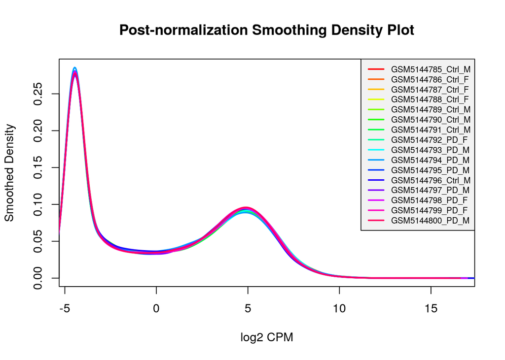

```r
# Calculate the density for each sample and plot it
plot(NULL, xlim = range(cpmDataPost),
     ylim = c(0, max(sapply(1:ncol(cpmDataPost), function(i) {
  max(density(cpmDataPost[, i])$y)
}))),
xlab = "log2 CPM", ylab = "Smoothed Density",
main = "Post-normalization Smoothing Density Plot")

# Add a color palette
colors <- rainbow(ncol(cpmDataPost))

# Plot the density for each sample
for (i in 1:ncol(cpmDataPost)) {
  dens <- density(cpmDataPost[, i])
  lines(dens, col = colors[i], lwd = 2)
}

# Add a legend to identify the samples
legend("topright", legend = colnames(cpmDataPost), cex=0.7, col = colors,
       bg = "gray95", lwd = 2)
```

Even though the density plot is very similar to the one before normalization, the curves become more overlapped. This implies that our normalization still works, even though it only improves the data by a little.

## 4. Discussion and Interpretation

### 4.1 MDS Plot

An MDS (Multidimensional scaling) plot is used to visualize the level of similarity of individual cases of a dataset. In our case, we can use it to show how similar or dissimilar the samples are from each other.

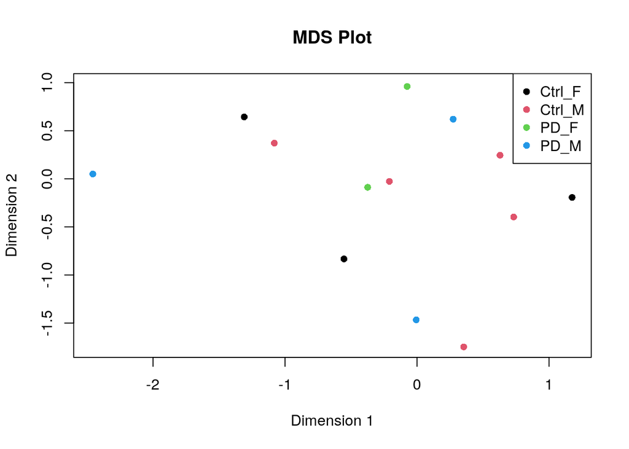

```r
# Extract the group information from the row names
# The pattern looks for "Ctrl" or "PD" followed by "_M" or "_F"
# and assigns to the corresponding parts of the group factor
dge$samples$group <-
  factor(gsub(".*(Ctrl|PD)_(M|F).*", "\\1_\\2", rownames(dge$samples)))

# First, you need to estimate the dispersions
dge <- edgeR::estimateDisp(dge, design = model.matrix(~1, data=dge$samples))

# Capture the output and use plot function
mdsData <- limma::plotMDS(dge, plot = FALSE)

# Plot the MDS data
plot(mdsData$x, mdsData$y,
     xlab = "Dimension 1",
     ylab = "Dimension 2",
     main = "MDS Plot",
     col = as.factor(dge$samples$group),
     pch = 16)

# Add a legend if necessary
legend("topright", legend=levels(as.factor(dge$samples$group)),
       col=1:length(levels(as.factor(dge$samples$group))),
       pch=16)
```

### 4.2 Mean Variance Plot

We will now use a mean-variance plot to visualize the relationship between the mean of normalized counts and the variance.

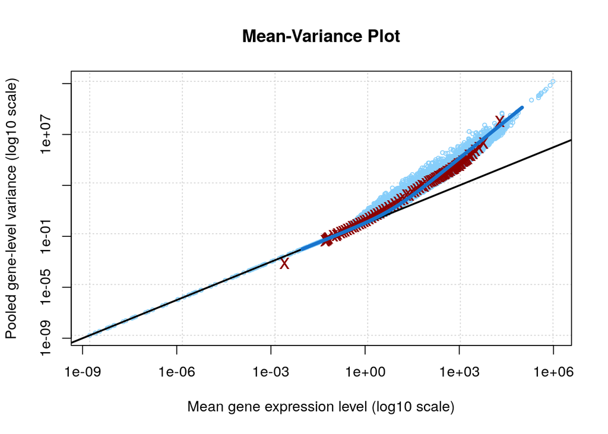

```r
# Estimate the mean-variance relationship
dge <- estimateDisp(dge, design = model.matrix(~group, data=dge$samples))

# Plot the mean-variance relationship
plotMeanVar(dge, show.tagwise.vars=TRUE, NBline=TRUE, main="Mean-Variance Plot")
```

```r
# 'show.tagwise.vars=TRUE' adds points to the plot for each tag (gene) showing the tagwise variance.
# 'NBline=TRUE' adds the expected negative binomial mean-variance relationship to the plot.
```

### 4.3 Dispersion Plot

We will now use a dispersion plot to assess the variability of gene expression data.

```r
# Estimate common dispersion
dge <- edgeR::estimateCommonDisp(dge, verbose=TRUE)
```

```
## Disp = 0.13218 , BCV = 0.3636
```

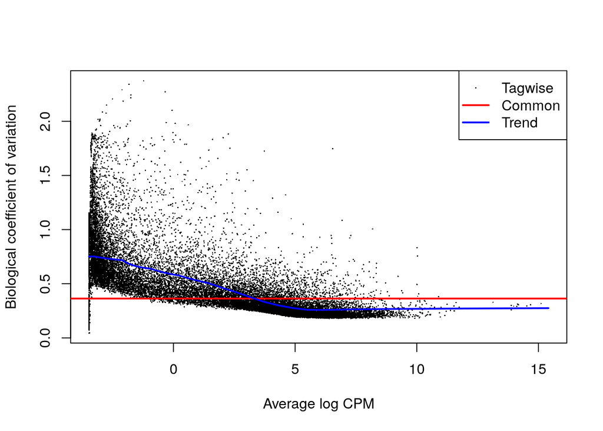

```r
# Estimate tagwise dispersion
dge <- edgeR::estimateTagwiseDisp(dge)

# Create a plot of the estimated dispersions
plotBCV(dge)
```

### 4.4 Assignment Questions

**Why is the dataset of interest to you?**

This study explores the sex-dependent differences in gene expression related to PD, which is a significant area of research. I am interested in Parkinson’s disease because there are currently no effective cure and it is complex given its chronic nature. Biological sex has been reported to influence the symptom profile of PD, with differences in disease incidence and symptom manifestation between males and females, and I am curious how it manifests itself defferently between male and female. I heard that biased data used for medicine development could cause underrepresented groups to benefit less from these medicines. Understanding these differences at a molecular level could have important implications for personalized medicine approaches to treating and managing PD.

**What are the control and test conditions of the dataset?**

Control Condition: Samples from individuals without Parkinson’s disease.

Test Condition: Samples from individuals diagnosed with Parkinson’s disease.

Additionally, the differential expression analyses were performed separately on datasets using only female or male samples to identify transcripts that display significant sex-dependent differences between Parkinson’s disease patients and controls.

**How many samples in each of the conditions of your dataset?**

There are 16 samples in total. 8 are non-demented controls, and the other 8 are patients with Parkinson’s. Among the 16 samples, 10 are male and 6 are females.

|  | Ctrl | PD |
| --- | --- | --- |
| Male | 5 | 5 |
| Female | 3 | 3 |

**Were there expression values that were not unique for specific genes? How did you handle these?**

According to<sup>1</sup>, the authors already addressed the issue of non-unique expression values by selecting the probe or transcript with the highest average expression across the datasets for inclusion in the meta-analysis. This approach was chosen because probes or transcripts with low signal are generally associated with lower reliability.

**Were there expression values that could not be mapped to current HUGO symbols?**

There are 19716 ENSEMBL IDs that could not be mapped to current HUGO symbols.

**Were there any outliers in your dataset? How were they handled in the originating paper? How many outliers were removed?**

In the original paper, outliers were identified and handled as part of the quality control process before raw data preprocessing. This was done using the R package ArrayQualityMetrics. The package employs three main methods for sample outlier detection. Any sample flagged as an outlier in at least two out of the three checks was removed from the analysis. According to this approach, a total of four samples across three datasets were identified as outliers and subsequently removed based on these standard filtering criteria.

**How did you handle replicates?**

According to<sup>1</sup>, the dataset has preprocessed in some ways. The authors handled duplicates or multiple probes/transcripts for the same gene by aggregating or selecting data to ensure specificity and relevance for their differential expression analyses. Here’s how they approached it:

Removing Irrelevant Probes/Transcripts: Before the differential expression analyses, probes and transcripts were cleaned to focus only on relevant entities. This step was crucial for probes, as transcripts are generally well-defined and associated with a single gene. First, probes associated with five or more genes were discarded to maintain focus on signals that are specific enough for straightforward interpretation. Second, probes that matched more than one gene were also discarded if there was another probe that matched a subset of these genes. For example, a probe matching both gene A and gene B was removed if another probe existed that matched only gene A or only gene B. Complex cases where probes matched overlapping sets of genes were removed because their interpretation would have been challenging. For instance, if two probes matched genes A+B and genes A+C, respectively, they were removed, regardless of the existence of probes matching only gene A, only gene B, or only gene C.

Building on top of it, I aggregated replicates when setting the row names to be HUGO symbols by summing them.

I chose to sum the duplicates because it:

- Strengthens Signal: Enhances detection of genes, especially those with low expression.
- Reduces Variability: Balances technical differences across probes or reads.
- Simplifies Data: Makes downstream analysis more straightforward by representing each gene with a single value.
- Improves Reproducibility: Standardizes data handling, promoting consistent results across studies.
- Uses All Data: Ensures no valuable information is lost, leveraging the full dataset for analysis.

**What is the final coverage of your dataset?**

The final dataset coverage is 28904 genes with 16 samples.

1.

Tranchevent, L.-C., Halder, R. & Glaab, E. [Systems level analysis of sex-dependent gene expression changes in parkinson’s disease](https://doi.org/10.1038/s41531-023-00446-8). *NPJ Parkinson’s Disease* **9**, 8 (2023).

2.

Neely, M. N., Guilder, M. G. van, Yamada, W. M., Schumitzky, A. & Jelliffe, R. W. [Accurate detection of outliers and subpopulations with pmetrics, a nonparametric and parametric pharmacometric modeling and simulation package for r](https://doi.org/10.1097/FTD.0b013e31825c4ba6). *Therapeutic Drug Monitoring* **34**, 467–476 (2012).

3.

Gough, A. H. *et al.* [Identifying and quantifying heterogeneity in high content analysis: Application of heterogeneity indices to drug discovery](https://doi.org/10.1371/journal.pone.0102678). *PLoS ONE* **9**, e102678 (2014).